# Analysing and Visualizing User Data

This notebook was part of a fun assignment I did to test my visualization and basic data wrangling skills. I used the following packages:

- Pandas and Numpy for data wrangling
- Seaborn and Matplotlib for visualization (Seaborn for actual graphs and pyplot, gridspec for refining the graphs)

```python
import pandas as pd
import seaborn as sns
import matplotlib.pyplot as plt
import matplotlib.gridspec as gs
import numpy as np
```

## The Data

The data provided by my mentor included two files. One providing information an actual usage statistics, and the other providing information about the account.

```python
data = pd.read_excel('Product Scorecard Metrics and ED Visits.xlsx')
hos_data = pd.read_csv('hospital data.csv')
```

```python
data.info()
```

```
<class 'pandas.core.frame.DataFrame'>
RangeIndex: 6902 entries, 0 to 6901
Data columns (total 22 columns):
 #   Column                                    Non-Null Count  Dtype
---  ------                                    --------------  -----
 0   id                                        6902 non-null   object
 1   Effective Start                           6902 non-null   datetime64[ns]
 2   Effective End                             6902 non-null   datetime64[ns]
 3   Facility Last Login(Days)                 6902 non-null   float64
 4   Ratio Days Logged In                      6902 non-null   float64
 5   Active Users                              6902 non-null   int64
 6   Total Users                               6902 non-null   int64
 7   Avg Time per User                         6902 non-null   float64
 8   Facility Distinct Days Logged In          6902 non-null   int64
 9   Time Logged In(Hours)                     6902 non-null   float64
 10  Notifications                             6902 non-null   int64
 11  Notifications Ratio                       6554 non-null   float64
 12  Avg Daily Reports Received                6902 non-null   float64
 13  Total Security Events Created This Month  6902 non-null   int64
 14  Patient Records Viewed                    6902 non-null   int64
 15  Total Actions                             6902 non-null   int64
 16  Engagement Level                          6886 non-null   object
 17  DAU/MAU                                   6888 non-null   float64
 18  ED Flu Visits with a Flu Diagnosis        6902 non-null   int64
 19  ED Flu Visits with a Flu Like Symptom     6902 non-null   int64
 20  ED Visits for Patients over 65            6902 non-null   int64
 21  ED Visits                                 6902 non-null   int64
dtypes: datetime64[ns](2), float64(7), int64(11), object(2)
memory usage: 1.2+ MB
```

```python
data.isnull().sum()
```

```
id                                            0
Effective Start                               0
Effective End                                 0
Facility Last Login(Days)                     0
Ratio Days Logged In                          0
Active Users                                  0
Total Users                                   0
Avg Time per User                             0
Facility Distinct Days Logged In              0
Time Logged In(Hours)                         0
Notifications                                 0
Notifications Ratio                         348
Avg Daily Reports Received                    0
Total Security Events Created This Month      0
Patient Records Viewed                        0
Total Actions                                 0
Engagement Level                             16
DAU/MAU                                      14
ED Flu Visits with a Flu Diagnosis            0
ED Flu Visits with a Flu Like Symptom         0
ED Visits for Patients over 65                0
ED Visits                                     0
dtype: int64
```

We begin with the following steps:

1. Create a column to identfy accounts as being active or inactive (This was a key question in the exercise)
2. Create a ratio to identify percentage of users who are active.
3. Define measurement period
4. Replace NAs with 0
5. Fix data types and ensure missing is categorised as such
6. Categorise accounts with missing engagement levels as red.

```python
data.loc[(data['Facility Last Login(Days)'] != 0), 'Active'] = 'Active'
data.loc[(data['Facility Last Login(Days)'] == 0), 'Active'] = 'Inactive'

data.loc[ (data['Active Users'] != 0) & (data['Total Users'] != 0),'active_total_ratio'] = data['Active Users'] / data['Total Users']
data.loc[ (data['Active Users'] == 0) | (data['Total Users'] == 0),'active_total_ratio'] = 0

data['Measurement Period'] = (data['Effective End'].dt.day - data['Effective Start'].dt.day)

#Creating index of columns with null values
null_col = hos_data.isnull().sum().sort_values(ascending = False)
null_col = null_col[ null_col > 0]
#Looping through to replace NAs with mean values
null_col = null_col.index
for col in null_col:
    hos_data.loc[:, col].fillna('0', inplace = True)

#Creating index of columns with null values
null_col = data.isnull().sum().sort_values(ascending = False)
null_col = null_col[ null_col > 0]
#Looping through to replace NAs with mean values
null_col = null_col.index
for col in null_col:
    data.loc[:, col].fillna(0, inplace = True)

hos_data['staffed_beds'] = hos_data['staffed_beds'].astype(int)
hos_data['number_discharges'] = hos_data['number_discharges'].astype(int)
hos_data['est_ED_visits'] = hos_data['est_ED_visits'].astype(int)
hos_data['average_LOS'] = hos_data['average_LOS'].astype(int)
hos_data['LWBS_rate'] = hos_data['LWBS_rate'].astype(int)

for col in ['join_date', 'region', 'geographic_classification', 'hospital_type', 'firm_type']:
    hos_data[col] = hos_data[col].apply(lambda x: 'missing' if x == '0' else x)

data['Engagement Level'] = data['Engagement Level'].apply(lambda x: 'Red' if x == 0 else x)
```

```python
data_login = data.query('''`Facility Last Login(Days)` != 0''')
```

### Simplifying numerical data

For visualization purposes, and to answer specific questions, I categorized most numerical data into bins. With more context and knowledge of the business, this can be done based on cut-offs and identified values.

```python
labels_4b = ['very low', 'low', 'medium', 'high']
labels_3b = ['low', 'medium', 'high']
labels_2b = ['low', 'high']
```

```python
%%capture [--no-stderr]
data_login['Login Level'], login_bins = pd.qcut(data_login['Facility Last Login(Days)'], q = [0, 0.25, 0.5, 0.75, 1], retbins= True, duplicates='drop', labels = labels_4b)
login_bins = np.concatenate(([-np.inf], login_bins[1:-1], [np.inf]))
data_login['Login Level'].value_counts()
```

```python
%%capture [--no-stderr]
data_login['Login Ratio Level'], login_ratio_bins = pd.qcut(data_login['Ratio Days Logged In'], q = [0, 0.25, 0.5, 0.75, 1], retbins= True, duplicates='drop', labels = labels_4b)
login_ratio_bins = np.concatenate(([-np.inf], login_ratio_bins[1:-1], [np.inf]))
data_login['Login Ratio Level'].value_counts()
```

```python
%%capture [--no-stderr]
data_login['Active User Level'], active_ratio_bins = pd.qcut(data_login['active_total_ratio'], q = [0, 0.25, 0.5, 0.75, 1], retbins= True, duplicates='drop', labels = labels_4b)
active_ratio_bins = np.concatenate(([-np.inf], active_ratio_bins[1:-1], [np.inf]))
data_login['Active User Level'].value_counts()
```

```python
%%capture [--no-stderr]
data_login['Time Per User Level'], time_user_bins = pd.qcut(data_login['Avg Time per User'], q = [0, 0.25, 0.5, 0.75, 1], retbins= True, duplicates='drop', labels = labels_4b)
time_user_bins = np.concatenate(([-np.inf], time_user_bins[1:-1], [np.inf]))
data_login['Time Per User Level'].value_counts()
```

```python
%%capture [--no-stderr]
data_login['Notification Levels'], notifications_bins = pd.qcut(data_login['Notifications'], q = [0, 0.25, 0.5, 0.75, 1], retbins= True, duplicates='drop', labels = labels_4b)
notification_bins = np.concatenate(([-np.inf], notifications_bins[1:-1], [np.inf]))
data_login['Notification Levels'].value_counts()
```

```python
data['Notification Level'] = pd.cut(data['Notifications'], bins = notification_bins, labels = labels_4b)
data['Time Per User Level'] = pd.cut(data['Avg Time per User'], bins = time_user_bins, labels = labels_4b)
data['Active User Level'] = pd.cut(data['active_total_ratio'], bins = active_ratio_bins, labels = labels_4b)
data['Login Ratio Level'] = pd.cut(data['Ratio Days Logged In'], bins = login_ratio_bins, labels = labels_4b)
data['Login Level'] = pd.cut(data['Facility Last Login(Days)'], bins = login_bins, labels = labels_4b)
data_nologin = data.query('''`Facility Last Login(Days)` == 0''')
```

```python
data_comp = data[['id', 'Total Users', 'Engagement Level', 'DAU/MAU', 'Active', 'Notification Level', 'Time Per User Level', 'Active User Level', 'Login Ratio Level', 'Login Level']]
data_comp = data_comp.merge(hos_data, on = 'id', how = 'left')
data_comp.info()

#Creating index of columns with null values
null_col = data_comp.isnull().sum().sort_values(ascending = False)
null_col = null_col[ null_col > 0]
#Looping through to replace NAs with mean values
null_col = null_col.index
for col in null_col:
    data_comp.loc[:, col].fillna(0, inplace = True)

for col in ['state','join_date', 'region', 'geographic_classification', 'hospital_type', 'firm_type']:
    data_comp[col] = data_comp[col].apply(lambda x: 'missing' if x == 0 else x)

data_comp = data_comp.query('''`state` != "missing"''')
data_comp = data_comp.query('''`firm_type` != "missing"''')
```

```
<class 'pandas.core.frame.DataFrame'>
Int64Index: 6902 entries, 0 to 6901
Data columns (total 21 columns):
 #   Column                     Non-Null Count  Dtype
---  ------                     --------------  -----
 0   id                         6902 non-null   object
 1   Total Users                6902 non-null   int64
 2   Engagement Level           6902 non-null   object
 3   DAU/MAU                    6902 non-null   float64
 4   Active                     6902 non-null   object
 5   Notification Level         6902 non-null   category
 6   Time Per User Level        6902 non-null   category
 7   Active User Level          6902 non-null   category
 8   Login Ratio Level          6902 non-null   category
 9   Login Level                6902 non-null   category
 10  state                      5307 non-null   object
 11  join_date                  5307 non-null   object
 12  staffed_beds               5307 non-null   float64
 13  number_discharges          5307 non-null   float64
 14  est_ED_visits              5307 non-null   float64
 15  average_LOS                5307 non-null   float64
 16  LWBS_rate                  5307 non-null   float64
 17  region                     5307 non-null   object
 18  geographic_classification  5307 non-null   object
 19  hospital_type              5307 non-null   object
 20  firm_type                  5307 non-null   object
dtypes: category(5), float64(6), int64(1), object(9)
memory usage: 951.4+ KB
```

### The Final Dataset

The final dataset used for visualizations below is the data_comp dataset. This combined both the files provided, created new variables for better visualization and also removed missing data. In reality, we cannot remove missing data, and instead would attempt to fix the data pipeline to ensure all data is capture.

## Visualizations

The questions in the exercise were as follows:

1. Which accounts are active or inactive? Where should we focus?
2. Is the current engagement level metric a fair measure? What are we missing out on?
3. Is there a difference in length of stay based on data of joining?

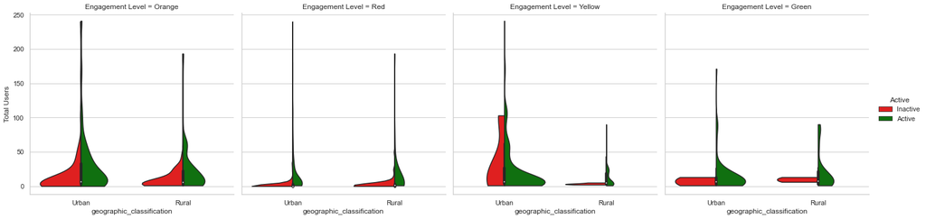

```python
act_palette = { 'Inactive': 'Red', 'Active' : 'Green'}
el_palette = {'Red' : 'Red', 'Yellow' : 'Yellow', 'Orange' : 'Orange', 'Green' : 'Green'}
_ = plt.figure(figsize = (25, 15));
_ = sns.set_theme(style = 'whitegrid');
_ = sns.catplot(data = data_comp, y = 'Total Users', x = 'geographic_classification', hue = 'Active', col = 'Engagement Level', palette=act_palette , alpha = 0.5, kind = 'violin', cut = 0, split = True);
```

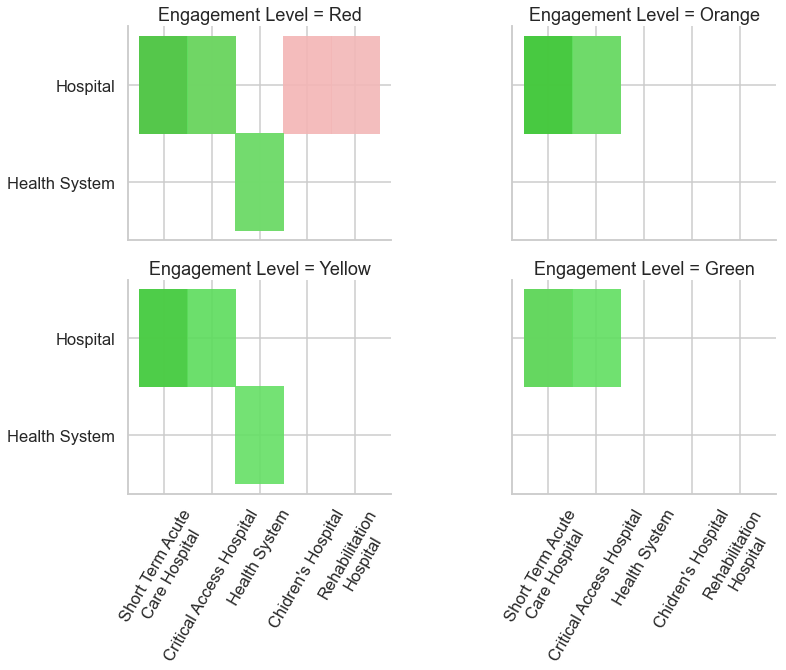

```python
sns.set_context('talk')
el_order = data_comp['Engagement Level'].value_counts().index
g = sns.displot(data = data_comp, x = 'hospital_type', y = 'firm_type', hue = 'Active', col = 'Engagement Level', col_wrap=2, alpha = 0.9,
                col_order = el_order, legend = False, hue_order = ['Inactive', 'Active'],
                kind = 'hist', palette=act_palette, height=4, aspect = 1.5)
g.set_xticklabels(labels = ['Short Term Acute\nCare Hospital', 'Critical Access Hospital', 'Health System', "Chidren's Hospital", 'Rehabilitation\nHospital'], rotation = 60)
g.set_xlabels('')
g.set_ylabels('')
g.savefig('fig2.png')
_ = plt.show()
```

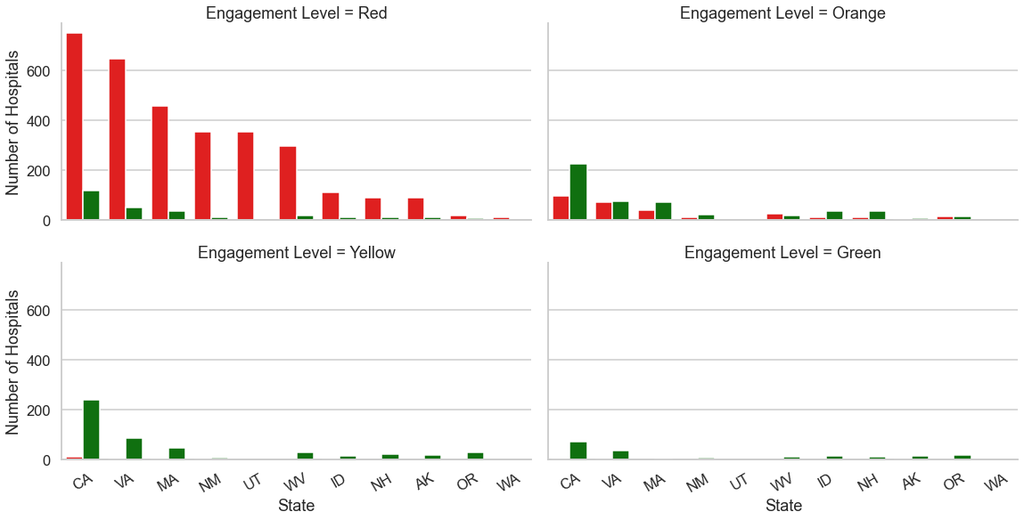

```python
act_palette = { 'Inactive': 'Red', 'Active' : 'Green'}
#plt.figure(figsize = (20, 20))
sns.set_context('talk')
g = sns.catplot(data = data_comp, x = 'state', col = 'Engagement Level',
                order = data_comp[['state', 'id', 'Active']].query('''`Active` == "Inactive"''').groupby('state').count().sort_values(by = 'id', ascending = False).index.to_list(),
                col_wrap= 2, hue = 'Active', height = 4, aspect = 2, kind = 'count', palette = act_palette, col_order = ['Red', 'Orange', 'Yellow', 'Green'],legend= False)
g.set_xticklabels(rotation=30)
g.set_xlabels("State")
g.set_ylabels("Number of Hospitals")
g.savefig('fig1.png')
_ = plt.show()
```

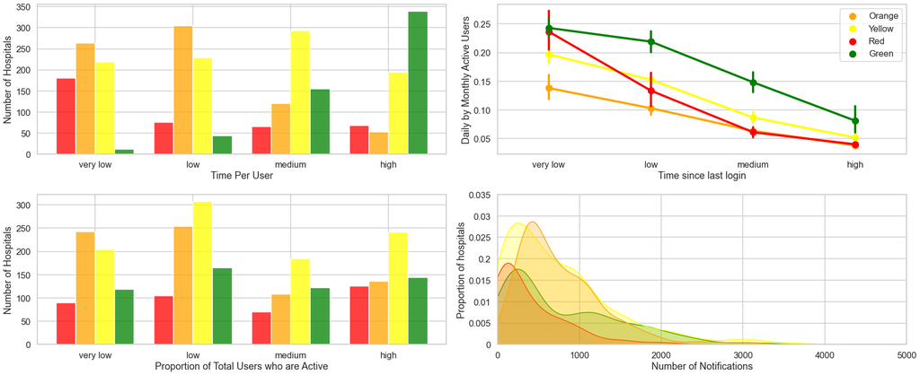

```python
fig = plt.figure(figsize = (24, 10))
gs.GridSpec(2,2)

plt.subplot2grid((2,2), (0,0))
sns.histplot(data_login, x = 'Time Per User Level', hue = 'Engagement Level', palette = el_palette,
             hue_order = ['Red', 'Orange', 'Yellow', 'Green'], legend = False,
             multiple = 'dodge', shrink = 0.8);
plt.xlabel('Time Per User')
plt.ylabel('Number of Hospitals')

plt.subplot2grid((2,2), (1,0))
sns.histplot(data_login, x = 'Active User Level', hue = 'Engagement Level', palette = el_palette,
             hue_order = ['Red', 'Orange', 'Yellow', 'Green'], legend = False,
             multiple = 'dodge', shrink = 0.8)
plt.xlabel('Proportion of Total Users who are Active')
plt.ylabel('Number of Hospitals')

plt.subplot2grid((2,2), (0,1))
sns.pointplot(data = data_login, y = 'DAU/MAU', x = 'Login Level', hue = 'Engagement Level',  palette = el_palette,
              alpha = 0.5, stat = 'probability', legend = False)
plt.legend(loc = 0)
plt.xlabel('Time since last login')
plt.ylabel('Daily by Monthly Active Users')

plt.subplot2grid((2,2), (1,1))
sns.kdeplot(data = data_login, x = 'Notifications', hue = 'Engagement Level',  palette = el_palette,
            legend = False, fill= True)
plt.xlim(0, 5000)
plt.xlabel('Number of Notifications')
plt.ylabel('Proportion of hospitals')
locs4, labs4 = plt.yticks()
plt.yticks(locs4, [0, 0.005, 0.010, 0.015, 0.20, 0.025, 0.030, 0.035])

fig.tight_layout()
#plt.subplots_adjust(right=0.9, top=0.9)
#fig.set_size_inches(w=24,h=10)
fig.savefig('fig3.png')
```

### Where do we focus?

Based on examination of active and inactive accounts, a few clear trends popped out. However for the second part of the question, I decided to dive deeper into accounts where:

- Engagement level is Red (Worst)
- Proportion of Active Users to Total Users is high.

Clearly there were many users in these accounts who were active and found utility, however, they had low levels of engagement.

```python
data_where = data.query('''`Engagement Level` == "Red"''')
data_where = data_where.query('''`Active User Level` == "high"''')
data_where = data_where.merge(hos_data, on = 'id', how = 'left')

#Creating index of columns with null values
null_col = data_where.isnull().sum().sort_values(ascending = False)
null_col = null_col[ null_col > 0]
#Looping through to replace NAs with mean values
null_col = null_col.index
for col in null_col:
    data_where.loc[:, col].fillna(0, inplace = True)

for col in ['state','join_date', 'region', 'geographic_classification', 'hospital_type', 'firm_type']:
    data_where[col] = data_where[col].apply(lambda x: 'missing' if x == 0 else x)

data_where = data_where.query('''`state` != "missing"''')
data_where = data_where.query('''`firm_type` != "missing"''')
```

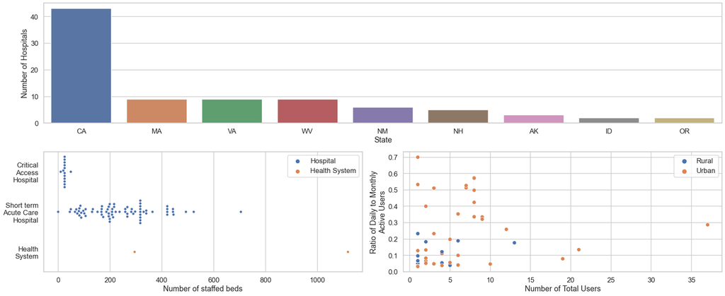

```python
sns.set_context('talk')
fig2 = plt.figure(figsize = (24, 10))
gs.GridSpec(2,2)

plt.subplot2grid((2,2), (0,0), rowspan = 1, colspan = 2)
sns.barplot(data = data_where, x = 'state', y = 'Total Users', estimator = lambda x:len(x),
                order = data_where[['state', 'Total Users']].groupby('state').count().sort_values(by = 'Total Users', ascending = False).index.to_list(),
                ci = False);
plt.xlabel("State")
plt.ylabel("Number of Hospitals")

plt.subplot2grid((2,2), (1, 0), rowspan = 1, colspan = 1)
sns.swarmplot(data = data_where, x = 'staffed_beds', y = 'hospital_type', hue = 'firm_type', size = 5.5)
labs10, ticks10 = plt.yticks()
plt.yticks(labels = ['Critical\nAccess\nHospital', 'Short term\nAcute Care\nHospital', 'Health\nSystem'], ticks = labs10, wrap = True)
plt.xlabel('Number of staffed beds')
plt.ylabel("")
plt.legend(title = '')

plt.subplot2grid((2,2), (1,1))
sns.scatterplot(data = data_where, x = 'Total Users', y = 'DAU/MAU', hue = 'geographic_classification')
plt.xlabel("Number of Total Users")
plt.ylabel("Ratio of Daily to Monthly\nActive Users")
plt.legend(title = '')


plt.tight_layout(pad = 1.0001)
plt.savefig('fig4.png')
_ = plt.show()
```

```python
query_data = hos_data.copy()
#Creating index of columns with null values
null_col = query_data.isnull().sum().sort_values(ascending = False)
null_col = null_col[ null_col > 0]
#Looping through to replace NAs with mean values
null_col = null_col.index
for col in null_col:
    query_data.loc[:, col].fillna(0, inplace = True)

for col in ['state','join_date', 'region', 'geographic_classification', 'hospital_type', 'firm_type']:
    query_data[col] = query_data[col].apply(lambda x: 'missing' if x == 0 else x)

query_data = query_data.query('''`state` != "missing"''')
query_data = query_data.query('''`firm_type` != "missing"''')
query_data = query_data.query('''`join_date` != "missing"''')
```

### Is there a difference based on join date?

```python
query_data['join_date'] = pd.to_datetime(query_data.join_date, format = '%m/%d/%Y')
import datetime
query_data['data_class'] = query_data['join_date'].apply(lambda x: 1 if x < datetime.datetime(2019, 1, 1) else 0)
```

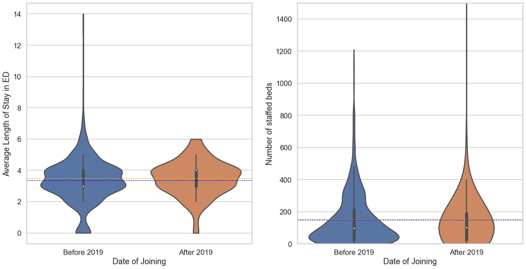

```python
fig3 = plt.figure(figsize = (20, 10));
gs.GridSpec(1,2)

mean_los = query_data.query('''`data_class` == 1''').loc[:, 'average_LOS'].mean()
mean_los2 = query_data.query('''`data_class` == 0''').loc[:, 'average_LOS'].mean()
plt.subplot2grid((1,2), (0,0))
sns.violinplot(data = query_data, y = 'average_LOS', x = 'data_class', cut = 0, order=[1,0]);
ticksv, labsv = plt.xticks()
_ = plt.xticks(labels = ['Before 2019', 'After 2019'], ticks = ticksv)
plt.axhline(y = mean_los, color = 'blue', linestyle = '--', linewidth = 1)
plt.axhline(y = mean_los2, color = 'orange', linestyle = '--', linewidth = 1)
plt.xlabel('Date of Joining')
plt.ylabel('Average Length of Stay in ED')

mean_sb = query_data.query('''`data_class` == 1''').loc[:, 'staffed_beds'].mean()
mean_sb2 = query_data.query('''`data_class` == 0''').loc[:, 'staffed_beds'].mean()
plt.subplot2grid((1,2), (0,1))
sns.violinplot(data = query_data, y = 'staffed_beds', x = 'data_class', order= [1,0])
plt.ylim(0, 1500)
ticksv, labsv = plt.xticks()
_ = plt.xticks(labels = ['Before 2019', 'After 2019'], ticks = ticksv)
plt.axhline(y = mean_sb, color = 'blue', linestyle = '--', linewidth = 1)
plt.axhline(y = mean_sb2, color = 'orange', linestyle = '--', linewidth = 1)
plt.xlabel('Date of Joining')
plt.ylabel('Number of staffed beds')

plt.savefig('fig5.png')
_ = plt.show()
```

# Conclusion

While this is a rudimnetary analysis based on a single snapshot of data, this gives rise to a fair number of questions which can help us monitor usage and develop features based on exploring these questions.